# A Model for Exercise Quality/Posture Determination

Ganesh Krishnamurthy

July 23, 2015

## Executive Summary:

This write-up provides details on the modeling approach.

### Data preparation:

Near zero covariates were identified after temporarily eliminating the “new window” records. This reduced the number of predictors from 159 to a manageable 58. Further removal of record-ID type fields (participant name, date/timestampt etc) yielded 52 predictors.

```r
training_exWindow<-subset(training, new_window=="no")
nsv<-nearZeroVar(training_exWindow,saveMetrics = TRUE)
training_clean<-training[,nsv$zeroVar==FALSE]
# Also remove non-sensical predictors like participant name date/timestamp/etc
training_clean<-training_clean[,-(1:6)]
```

### Implementing 10-Fold Cross Validation:

This was done using the “trainControl” functionality in the Caret package

```r
train_control_10k_CV<-trainControl(method="cv", number=10)
```

### Base Exploratory Model Creation - Simple TREE:

As a first blind stab at model creation, a decision tree was attempted with all predictors and 10-fold cross validation. This yielded high miss-classification and **just 47% accuracy**.

```r
modFit_tree_raw<-train(classe ~ ., method="rpart", data=training_clean, trControl=train_control_10k_CV)
```

**This stressed the need for better pre-processing of the data and an advanced machine learning algorithms.**

### Principal Component Analysis/Creation:

When 52 predictors (and 19,622 records) were fed to a random forest model as part of preliminary analysis, my computer’s memory requirements were exceeded. Also, a correlation analysis revealed that multiple predictors were correlated and the dataset needed dimension reduction.

```r
## Identify correlated predictors
Cor_Mat<-abs(cor(training_clean[,-53]))
diag(Cor_Mat)<-0 # Remove the diagonal (all 1)
summary(Cor_Mat[upper.tri(Cor_Mat)])
```

```
##      Min.   1st Qu.    Median      Mean   3rd Qu.      Max.
## 0.0000018 0.0330200 0.1042000 0.1697000 0.2412000 0.9920000
```

```r
corr_preds<-which(Cor_Mat > 0.8, arr.ind=TRUE)
```

Principal components were generated and the number of components required to capture **80% proportion of variance** was identified as **12**.

```r
pc_comp<-prcomp(training_clean[,-53], scale.=TRUE)
```

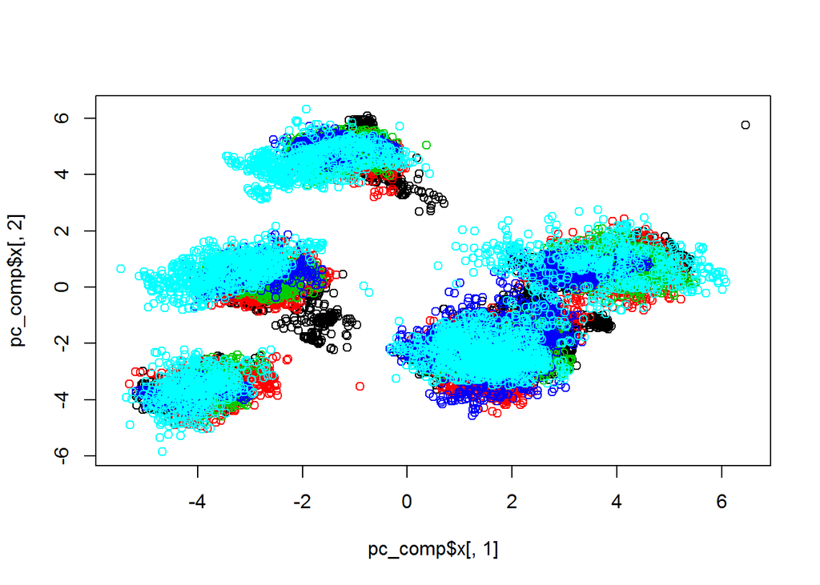

```r
pcaObj<-preProcess(training_clean[,-53], method="pca", thresh=0.8)
training_PC<-predict(pcaObj, training_clean[,-53])
training_PC<-data.frame(training_PC, classe=training_clean$classe)
```

### Other Models/Machine Learning Algorithms Attempted:

Both a boosted tree model and a linear discriminant analysis were attempted using 10-fold cross validation on 12 principal component predictors.

```r
## Boosting
modFit_boost<-train(classe ~ ., data=training_PC, method="gbm", verbose=FALSE,
                    trControl=train_control_10k_CV)
# Classification accuracy of boosting
confusionMatrix(training_PC$classe, predict(modFit_boost, training_PC[,-13]))
# Result: 78.49% estimated out of sample accuracy

## Linear Discriminant Analysis
modFit_lda<-train(classe ~., data=training_PC, method="lda", trControl=train_control_10k_CV)
# Classification accuracy of LDA
confusionMatrix(training_PC$classe, predict(modFit_lda, training_PC[,-13]))
# Result: 47% estimated out of sample accuracy
```

The boosted tree model had an accuracy of 78%, while the linear discriminant analysis has only 47% accuracy. So, search for a better model continued.

### Winning/final Model: Random Forest on Principal Components:

```r
modFit_randForest_10cv<-train(classe ~ ., method="rf", data=training_PC, trControl=train_control_10k_CV)
## Print the model summary
modFit_randForest_10cv
```

```
## Random Forest
##
## 19622 samples
##    12 predictor
##     5 classes: 'A', 'B', 'C', 'D', 'E'
##
## No pre-processing
## Resampling: Cross-Validated (10 fold)
##
## Summary of sample sizes: 17659, 17660, 17658, 17660, 17661, 17661, ...
##
## Resampling results across tuning parameters:
##
##   mtry  Accuracy   Kappa      Accuracy SD  Kappa SD
##    2    0.9698819  0.9618982  0.004896342  0.006196119
##    7    0.9637660  0.9541691  0.004306697  0.005448424
##   12    0.9592298  0.9484331  0.004433272  0.005606171
##
## Accuracy was used to select the optimal model using  the largest value.
## The final value used for the model was mtry = 2.
```

## Estimating Out of Sample Error of Random Forest (winning) Model

The property/structure of random forests is such it uses bootstrap samples internally and one-third of the records/cases are held out from construction of the k-th tree. This allows us to calculate Out of Bag (OOB) errors and the OOB error is typically an unbiased estimate of the error expected on an out of sample record (i.e., a “test” record). For the random forest model, **the out of sample error is estimated to be 2.61% using the ‘Out of Bag’ approach/metric**

```r
modFit_randForest_10cv$finalModel
```

```
##
## Call:
##  randomForest(x = x, y = y, mtry = param$mtry)
##                Type of random forest: classification
##                      Number of trees: 500
## No. of variables tried at each split: 2
##
##         OOB estimate of  error rate: 2.61%
## Confusion matrix:
##      A    B    C    D    E class.error
## A 5499   22   38   16    5  0.01451613
## B   71 3656   56   10    4  0.03713458
## C   14   39 3336   27    6  0.02513150
## D   20    8  110 3072    6  0.04477612
## E    2   18   20   21 3546  0.01691156
```

```r
confusionMatrix(training_PC$classe, predict(modFit_randForest_10cv, training_PC[,-13]))
```

```
## Confusion Matrix and Statistics
##
##           Reference
## Prediction    A    B    C    D    E
##          A 5580    0    0    0    0
##          B    0 3797    0    0    0
##          C    0    0 3422    0    0
##          D    0    0    0 3216    0
##          E    0    0    0    0 3607
##
## Overall Statistics
##
##                Accuracy : 1
##                  95% CI : (0.9998, 1)
##     No Information Rate : 0.2844
##     P-Value [Acc > NIR] : < 2.2e-16
##
##                   Kappa : 1
##  Mcnemar's Test P-Value : NA
##
## Statistics by Class:
##
##                      Class: A Class: B Class: C Class: D Class: E
## Sensitivity            1.0000   1.0000   1.0000   1.0000   1.0000
## Specificity            1.0000   1.0000   1.0000   1.0000   1.0000
## Pos Pred Value         1.0000   1.0000   1.0000   1.0000   1.0000
## Neg Pred Value         1.0000   1.0000   1.0000   1.0000   1.0000
## Prevalence             0.2844   0.1935   0.1744   0.1639   0.1838
## Detection Rate         0.2844   0.1935   0.1744   0.1639   0.1838
## Detection Prevalence   0.2844   0.1935   0.1744   0.1639   0.1838
## Balanced Accuracy      1.0000   1.0000   1.0000   1.0000   1.0000
```